# ggplot2の辞書

## 4.5 グラフ中に線やテキストを追加

### 4.5.1 縦線:geom_vline()

- 軸がカテゴリの場合は、左から1ずつ数える
  - ここでは、5を指定しているので5本目の部分に線が引かれている

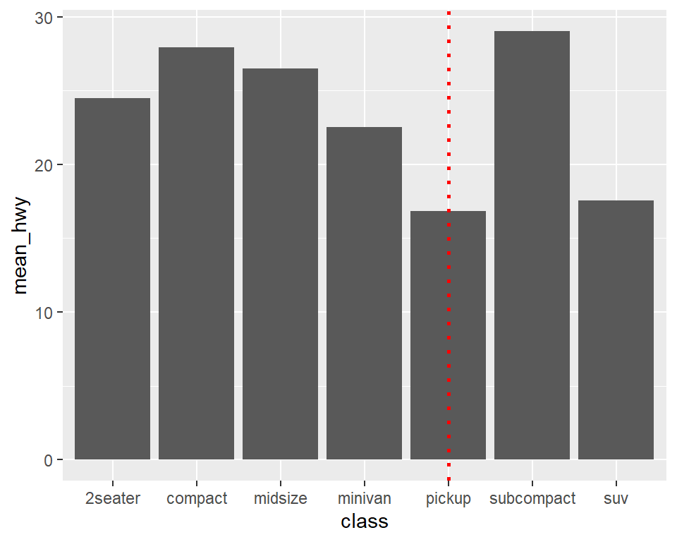

```r
pb +
  geom_col() +
  geom_vline(xintercept = 5,
             linetype = "dotted",
             color = "red",
             size = 1)
```

### 4.5.2 テキスト: annotate()

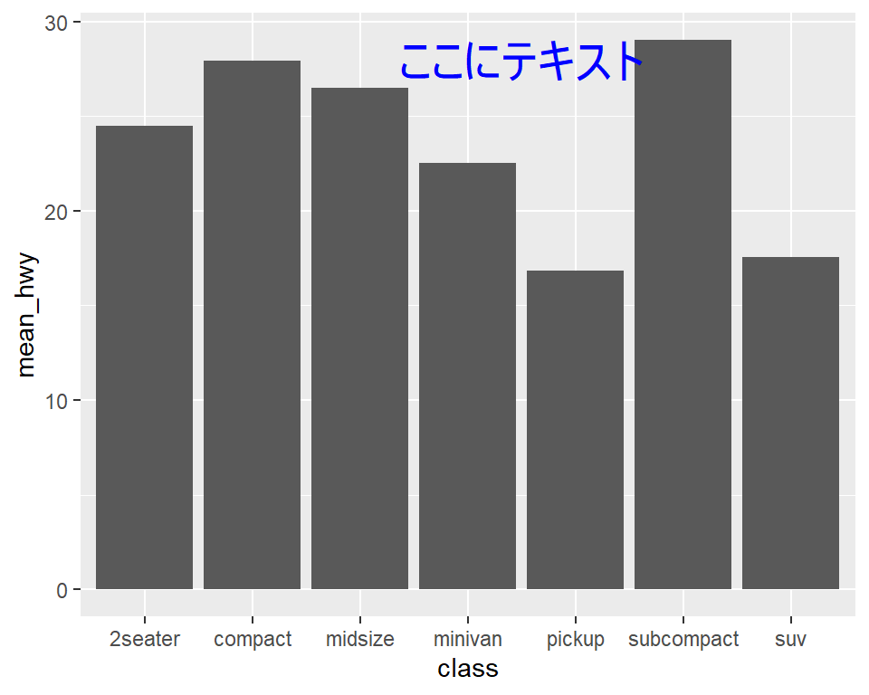

```r
pb +
  geom_col() +
  annotate(geom = "text",
           x = 4.5, y = 28,  # テキストの中心座標位置
           label = "ここにテキスト",
           color = "blue",
           size = 7)
```

## 4.6 横向きに

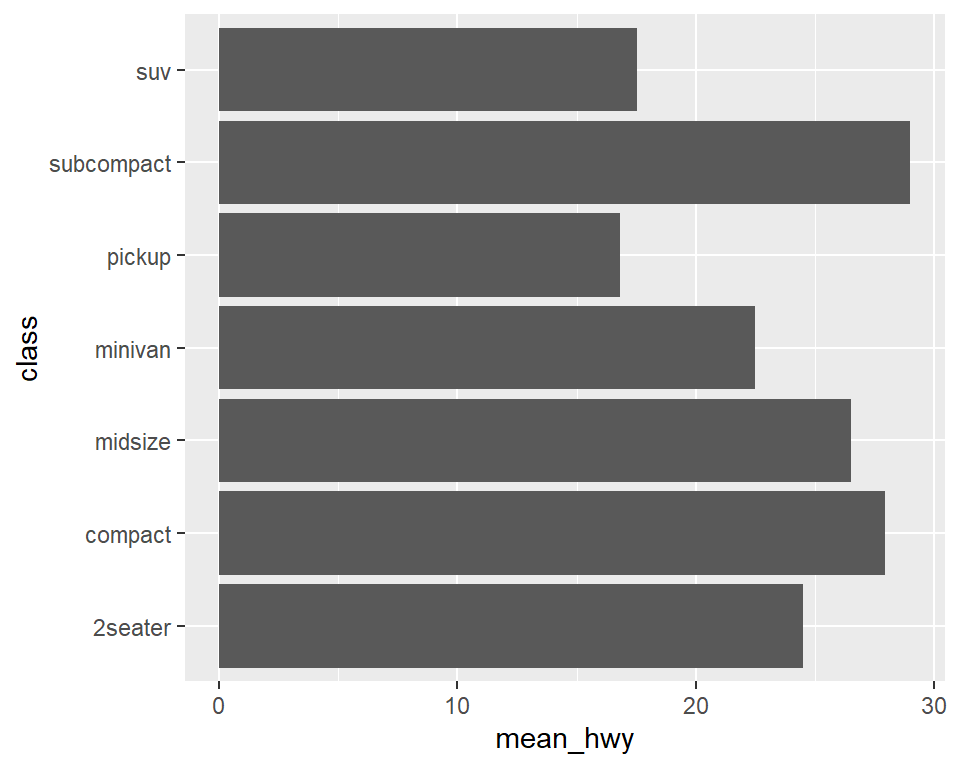

```r
pb  +
  geom_col() +
  coord_flip()
```

### 4.6.1 横向きのグラフ外にテキスト追加

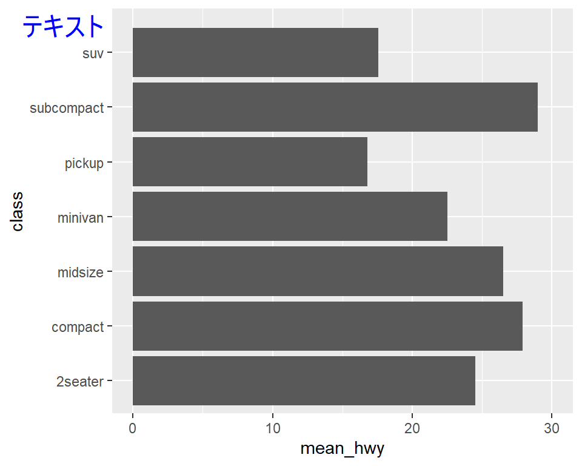

```r
pb  +
  geom_col() +
  annotate(geom = "text",
           x = 7.5, y = -5,  # テキストの中心座標位置,表示されるグラフの見かけはXYが入れ替わる
           color = "blue",
           size = 6,
           label = "テキスト") +
   coord_flip(xlim = c(1, 7.2),
                  ylim = c(0, 30),
                  clip = "off")
```

# 5 棒グラフ(2要因以上；要約値から)

- 折れ線グラフの時と同一データを使用
  - yearの限定なし

## 5.1 デフォルトの図

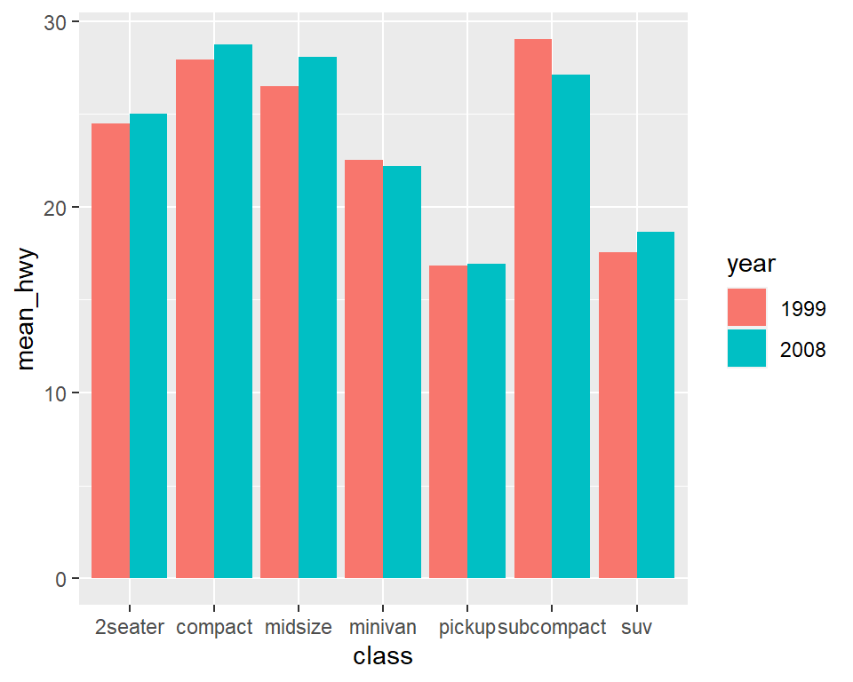

```r
pby <-
   ggplot(hwy_class_y,
          aes(x = class, y = mean_hwy, fill = factor(year)))

pby +
  geom_col(position = "dodge") +
  labs(fill = "year")             # 凡例のタイトル名をyearに戻す
```

## 5.2 色を手動で指定

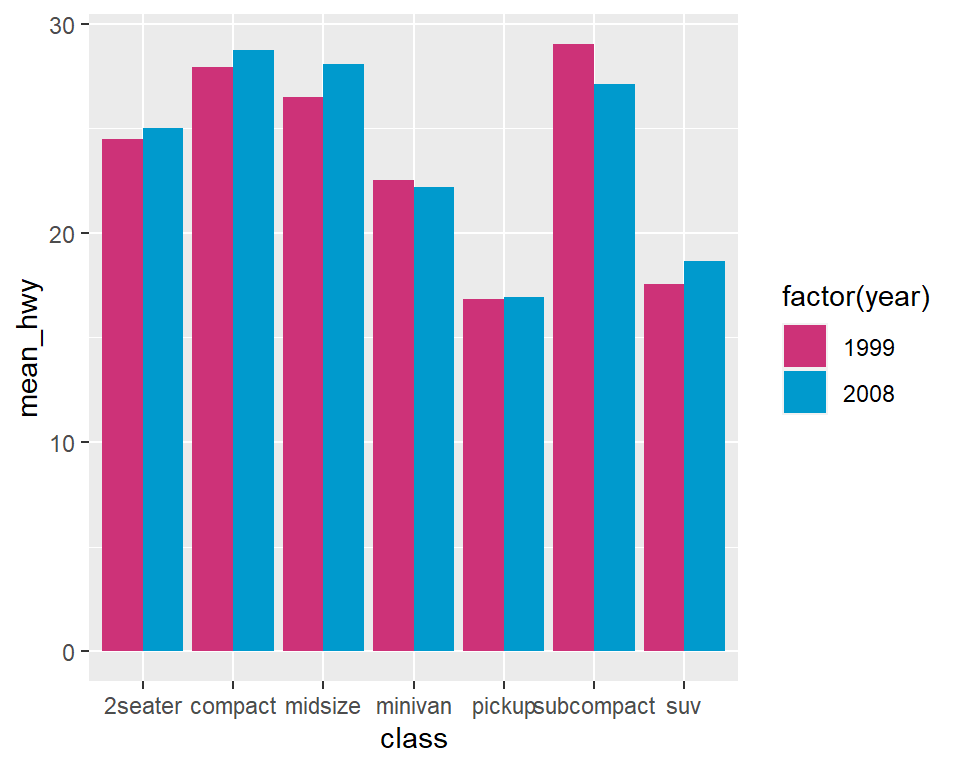

```r
pby +
  geom_col(position = "dodge") +
  scale_fill_manual(values = c("violetred3", "deepskyblue3"))
```

## 5.3 値ラベル

### 5.3.1 値ラベルを表示

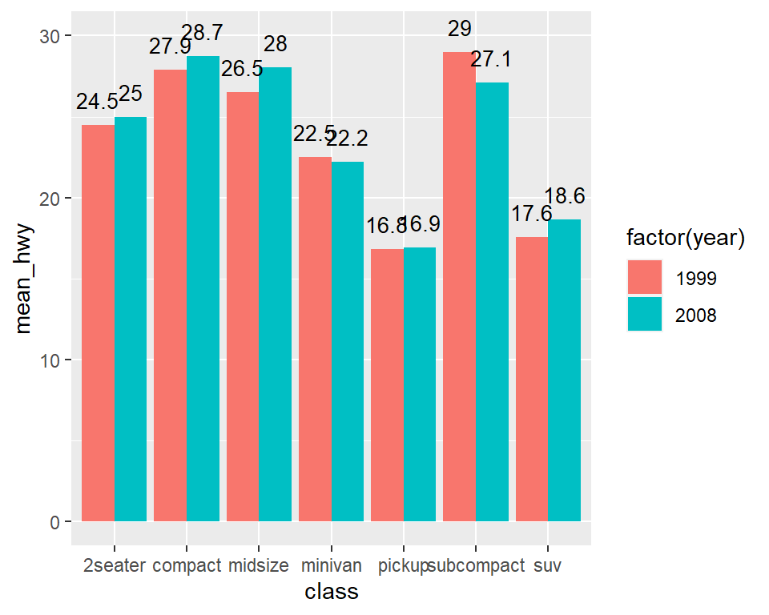

```r
pby +
  geom_col(position = "dodge") +
  geom_text(aes(label = round(mean_hwy, 1)),
            vjust = -1,
            position = position_dodge(width = 0.9), # ラベルを棒ごとに表示させる
            size = 3.5) +
  scale_y_continuous(limits = c(0, 30))
```

# 6 棒グラフ（カウントや割合）：geom_bar()

## 6.1 デフォルトの図

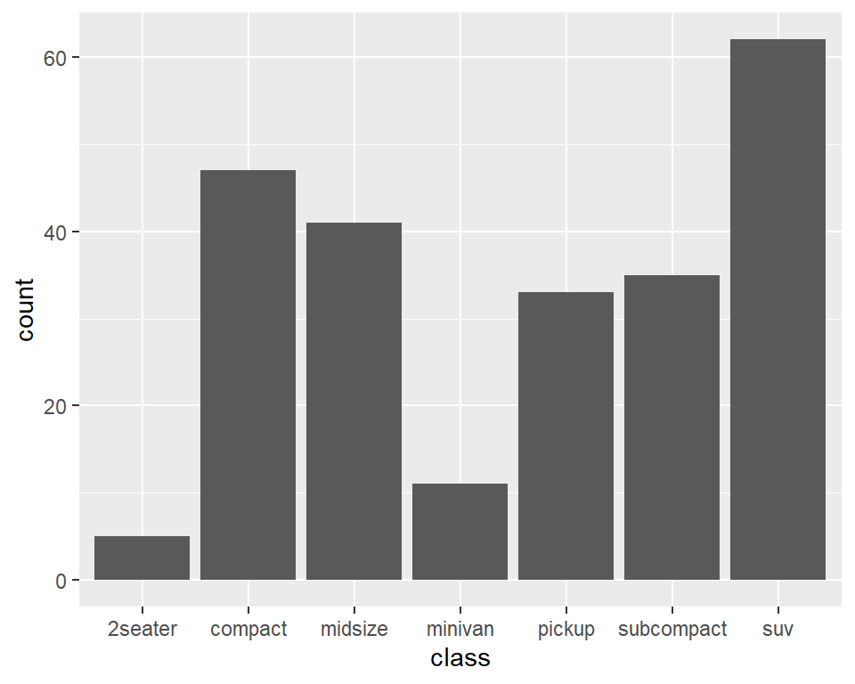

```r
pbar <-
ggplot(mpg, aes(x = class))

pbar +  geom_bar()
```

### 6.1.1 ラベルを付ける

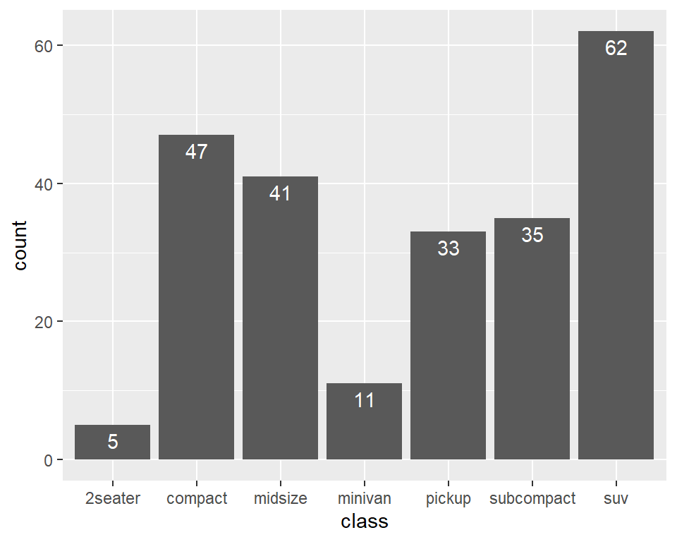

```r
pbar +
  geom_bar() +
  geom_text(aes(label = ..count..),
            stat = "count",
            vjust = 1.5,
            color = "white") # 棒の上に黒い文字で出したい場合はこれを削除し、vjustを0.5に
```

## 6.2 カテゴリ変数1つだけで1本の棒グラフ

- 1変数だけの場合は、`x = factor(1)`と固定する
- 円グラフ参照

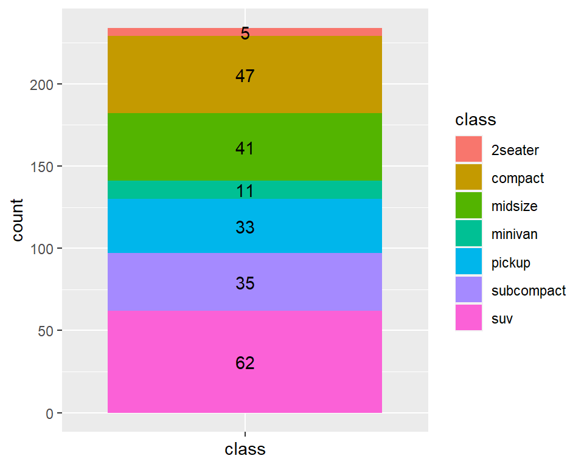

```r
ggplot(mpg,
       aes(x = factor(1), fill = class)) +
  geom_bar() +
  labs(x = "class") +
  geom_text(aes(label = ..count..),
            stat = "count",
            position = position_stack(vjust = 0.5)) +
  theme(axis.text.x = element_blank())                # 軸の1を消す
```

## 6.3 カテゴリ変数1つだけで1本の棒グラフ（割合）

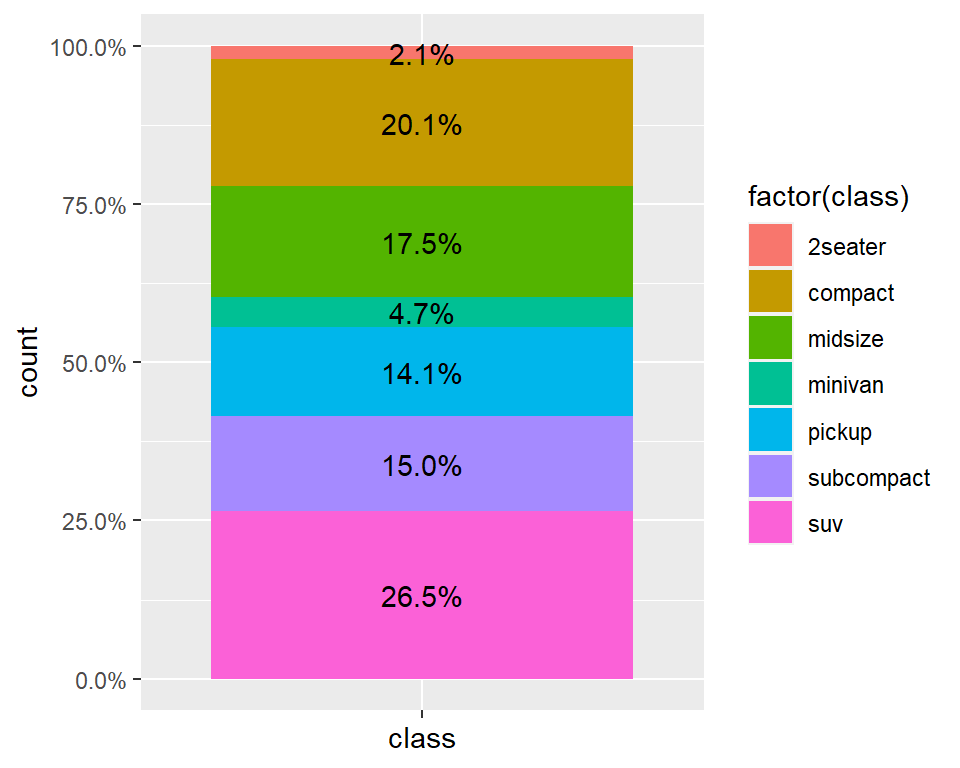

```r
# まずパーセントのデータを別途作成
percent <-
  mpg %>%
  count(class) %>%
  mutate(pct = scales::percent_format(accuracy = 0.1)(n/sum(n)))

# グラフ
ggplot(mpg, aes(x = factor(1), fill = factor(class))) +
  geom_bar(position = "fill") +
  geom_text(data = percent,  # 上で作ったパーセントのデータ指定
            aes(y = n, label = pct),
            position = position_fill(vjust = 0.5)) +
    scale_y_continuous(labels = scales::label_percent(accuracy = 0.1)) +   # y軸を%表記に
    theme(axis.text.x = element_blank()) +           # x軸の1を消す
  labs(x = "class")                                  # x軸の名前をclassに
```

## 6.4 2要因でカウント

- `drv`:ドライブトレインのタイプ
  - f = 前輪駆動, r = 後輪駆動, 4 = 四輪駆動

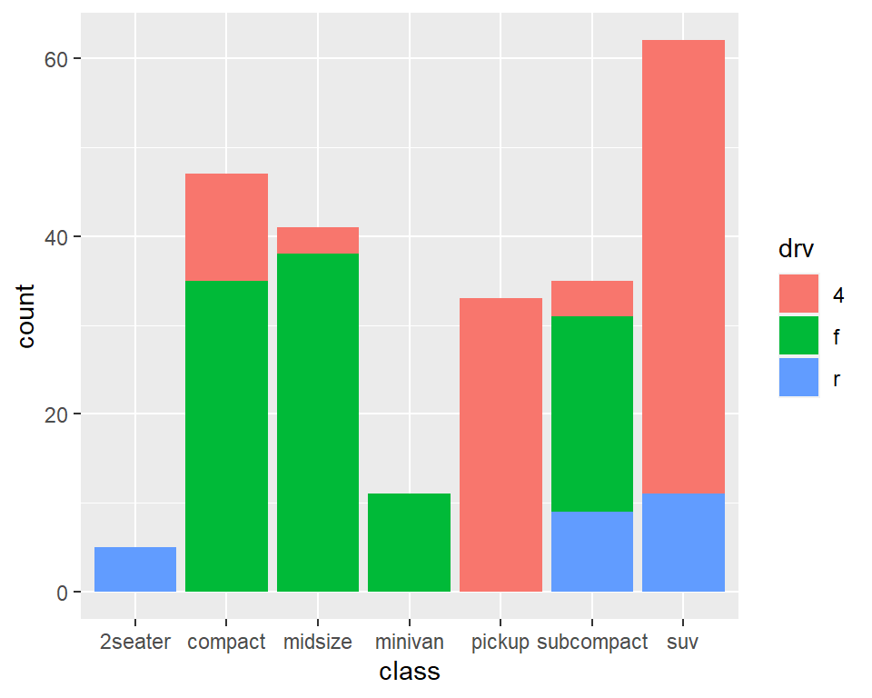

```r
pbar +
  geom_bar(aes(fill = drv))
```

### 6.4.1 ラベルを付ける

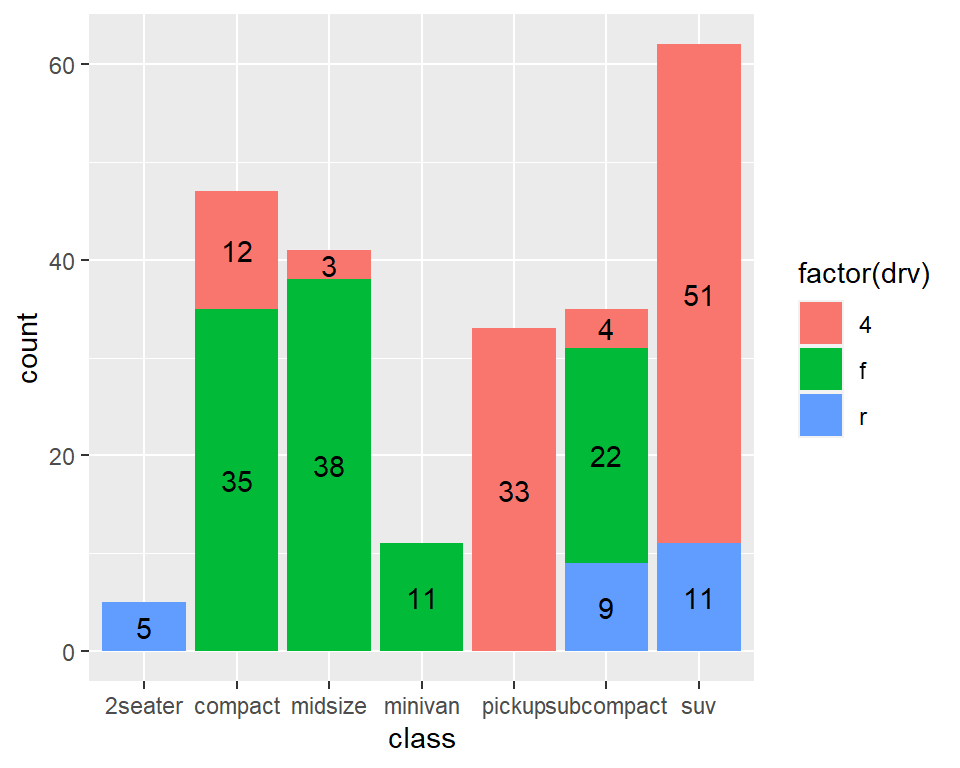

```r
pbar +
  geom_bar(aes(fill = factor(drv))) +
  geom_text(aes(fill = factor(drv),
                label = ..count..),
                stat = "count",
            position = position_stack(vjust = 0.5))
```

### 6.4.2 x軸の要因の水準ごとに割合として表示

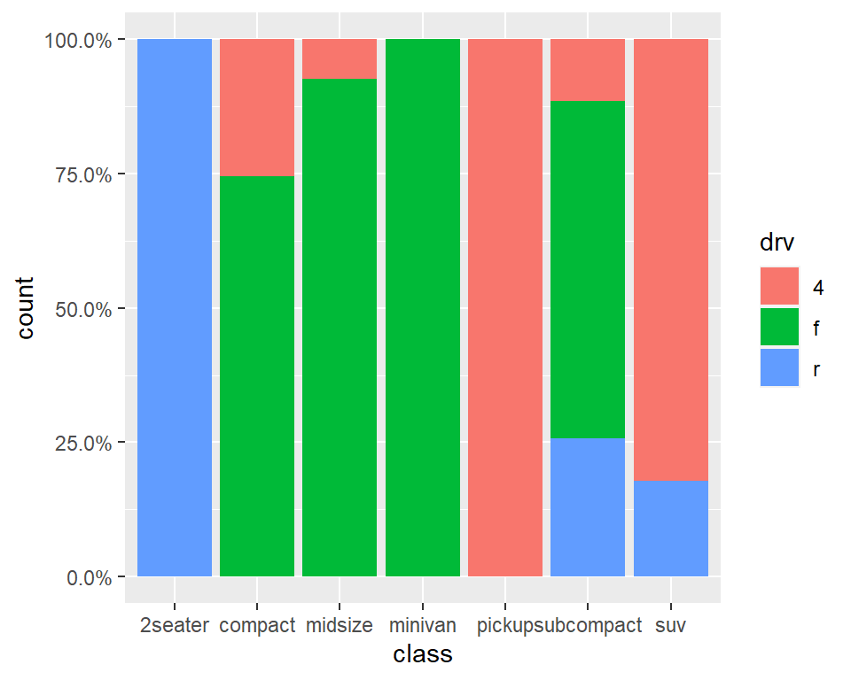

```r
pbar +
  geom_bar(aes(fill = drv),
           position = "fill") +
    scale_y_continuous(labels = scales::label_percent(accuracy = 0.1)) # 縦軸を%表記に
```

#### 6.4.2.1 パーセントを表示

- 小数点第1位まで表示させるために`accuracy = 0.1`をつける
  - 参考：https://stackoverflow.com/questions/59396655/how-to-always-have-fixed-number-of-decimals-in-ggplot-geom-text

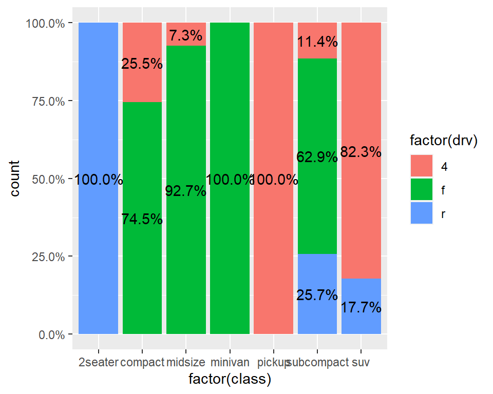

```r
# まずグラフ上に表示するテキストラベルのためにパーセントのデータを別途作成
df_pct <-
  mpg %>%
  group_by(class) %>%
  count(class, drv) %>%
  mutate(pct_num = n/sum(n),
         pct = scales::percent_format(accuracy = 0.1)(pct_num))

# old
# scales::percent(pct_num)

# グラフ
ggplot(mpg, aes(x = factor(class), fill = factor(drv))) +
  geom_bar(position = "fill") +
  geom_text(data = df_pct,  # 上で作ったパーセントのデータ指定
            aes(y = n, label = pct),
            position = position_fill(vjust = 0.5)) +
    scale_y_continuous(labels = scales::label_percent(accuracy = 0.1)) # 縦軸を%表記に
```

### 6.4.3 積み上げではなく並べる

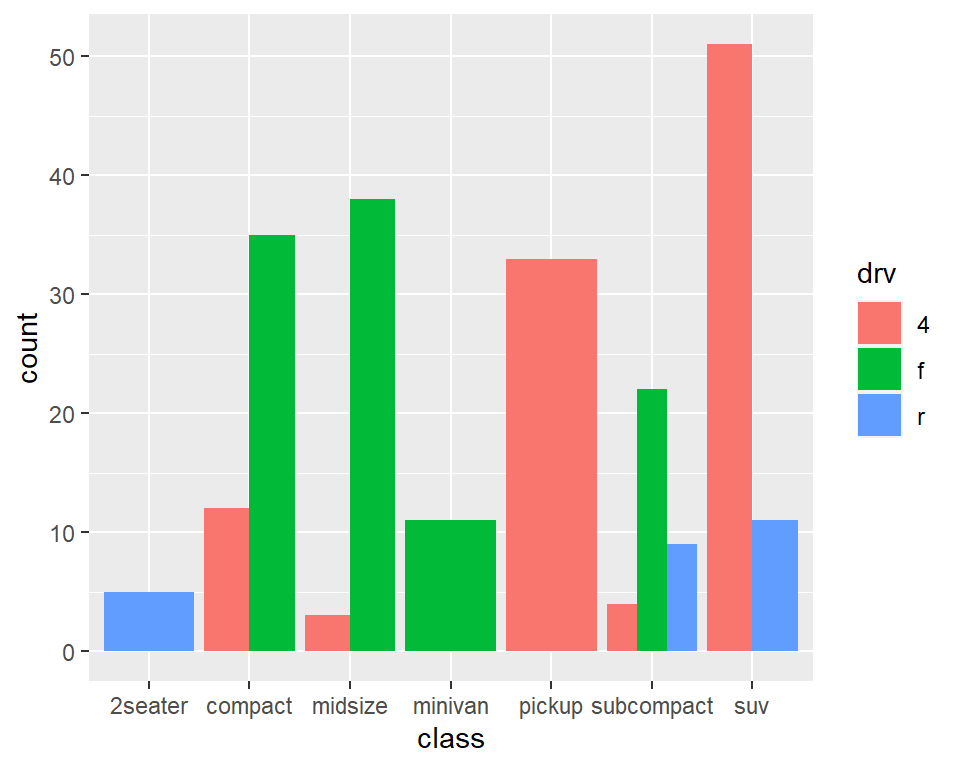

```r
pbar +
  geom_bar(aes(fill = drv), position = "dodge")
```

#### 6.4.3.1 棒の間に隙間を作る

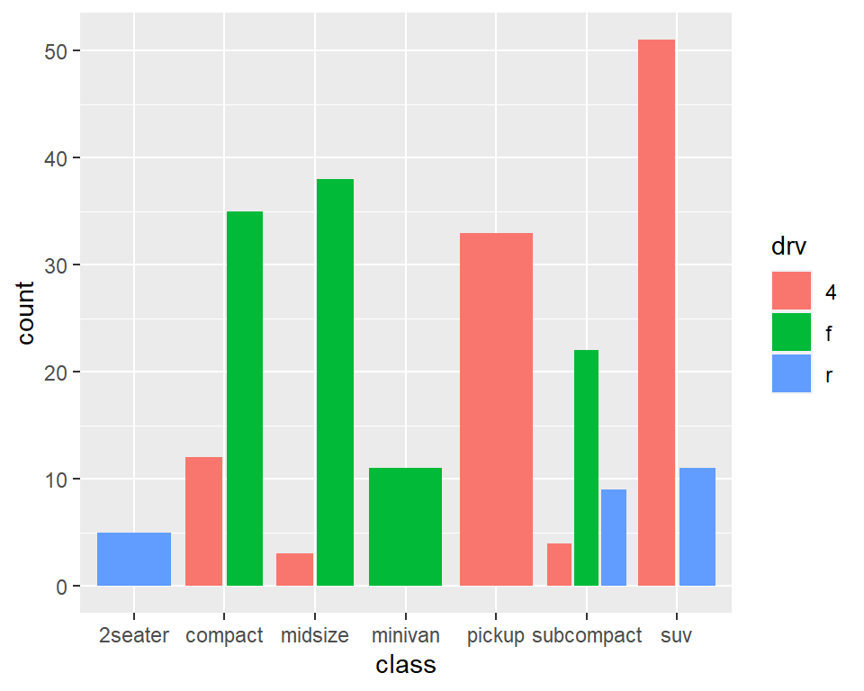

```r
pbar +
  geom_bar(aes(fill = drv), position = "dodge2")
```

#### 6.4.3.2 水準が少ない場合も棒が太くならないようにする

- 細かい設定を行っていく場合は、`position_dodge()`の中で指定していく

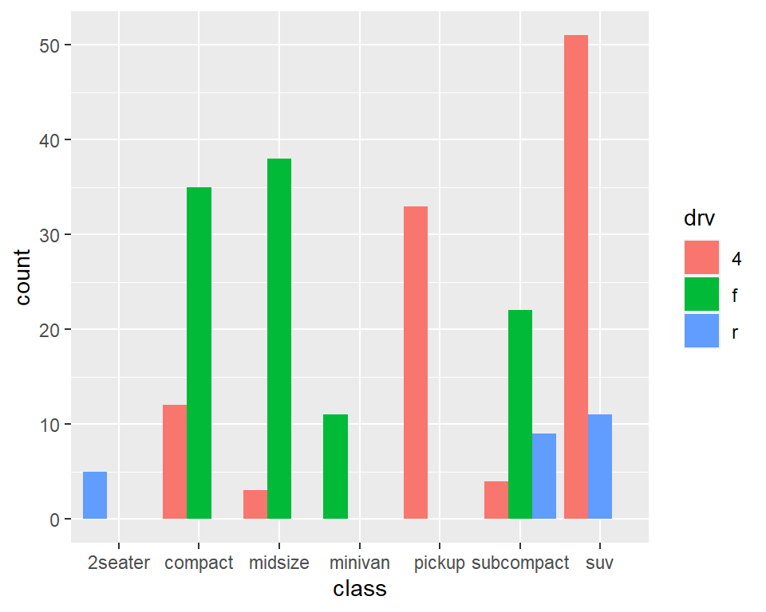

```r
pbar +
  geom_bar(aes(fill = drv),
           position = position_dodge(preserve = "single"))
```

##### 6.4.3.2.1 棒の位置を真ん中にして棒の間を広げる

- 棒の間を広げる設定は`position_dodge2()`

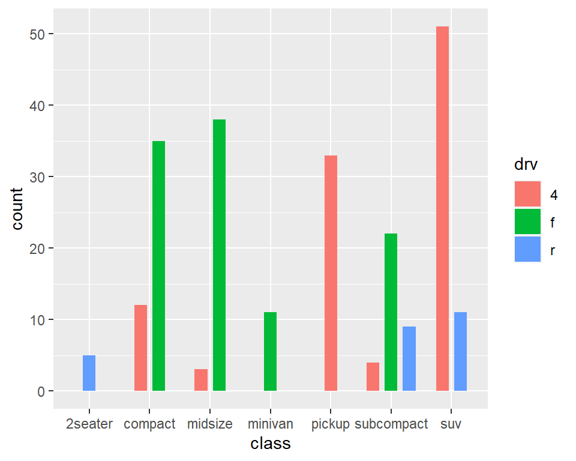

```r
pbar +
  geom_bar(aes(fill = drv),
           position = position_dodge2(preserve = "single",
                                      pad = 0.3))
```

# 7 円グラフ

- カテゴリ変数1つだけで1本の棒グラフを円にしたもの

## 7.1 count

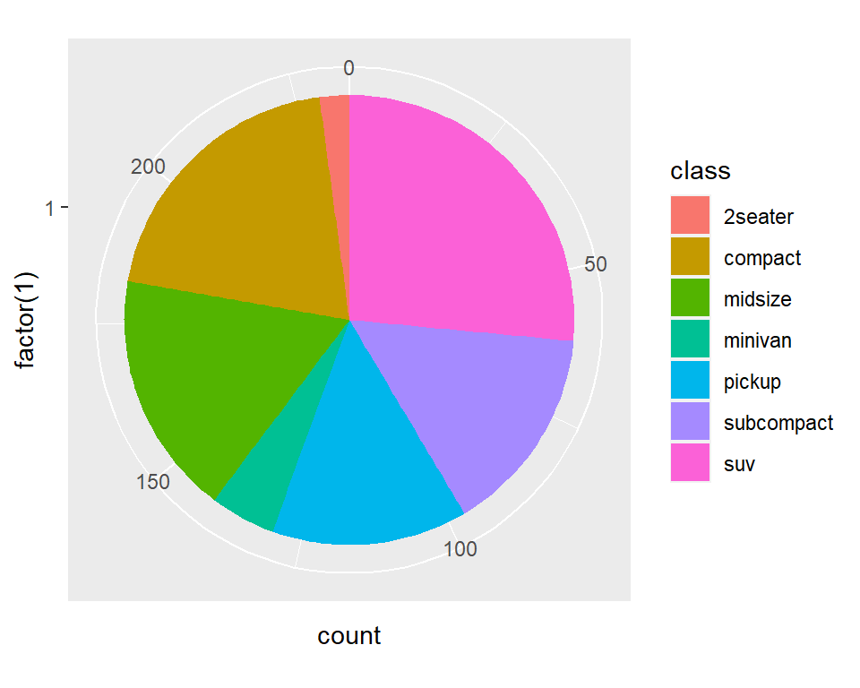

```r
ggplot(mpg,
       aes(x = factor(1), fill = class)) +
  geom_bar() +
  coord_polar(theta = "y")
```

### 7.1.1 色変更

#### ユニバーサルカラー

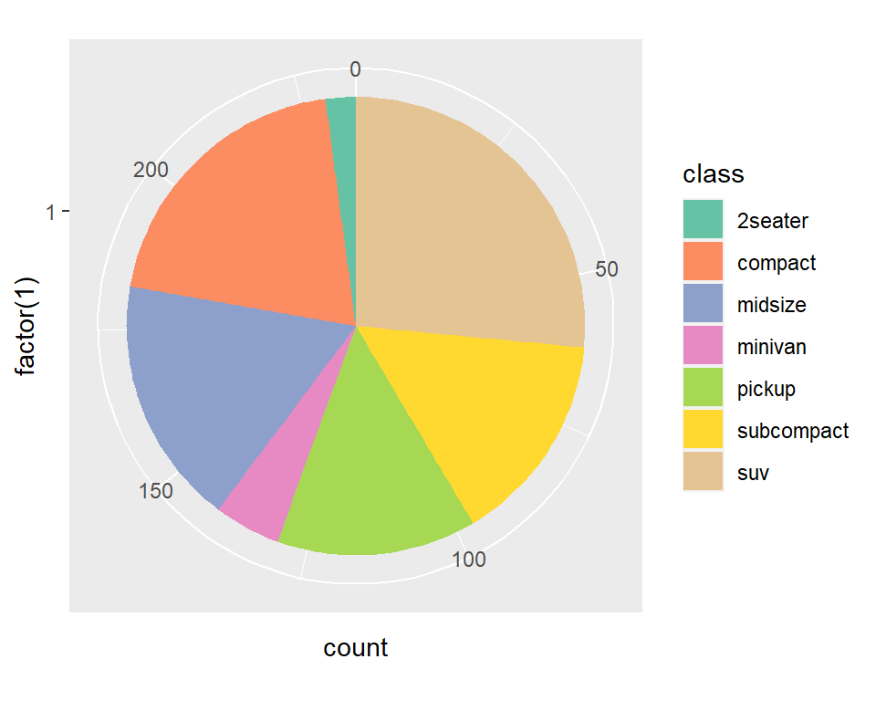

```r
ggplot(mpg,
       aes(x = factor(1), fill = class)) +
  geom_bar() +
  scale_fill_brewer(palette = "Set2") +
  coord_polar(theta = "y")
```

#### 背景なし{-}

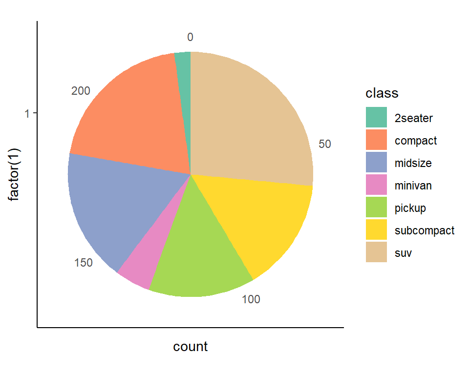

```r
ggplot(mpg,
       aes(x = factor(1), fill = class)) +
  geom_bar() +
  scale_fill_brewer(palette = "Set2") +
  coord_polar(theta = "y") +
  theme_classic()
```

## 7.2 割合

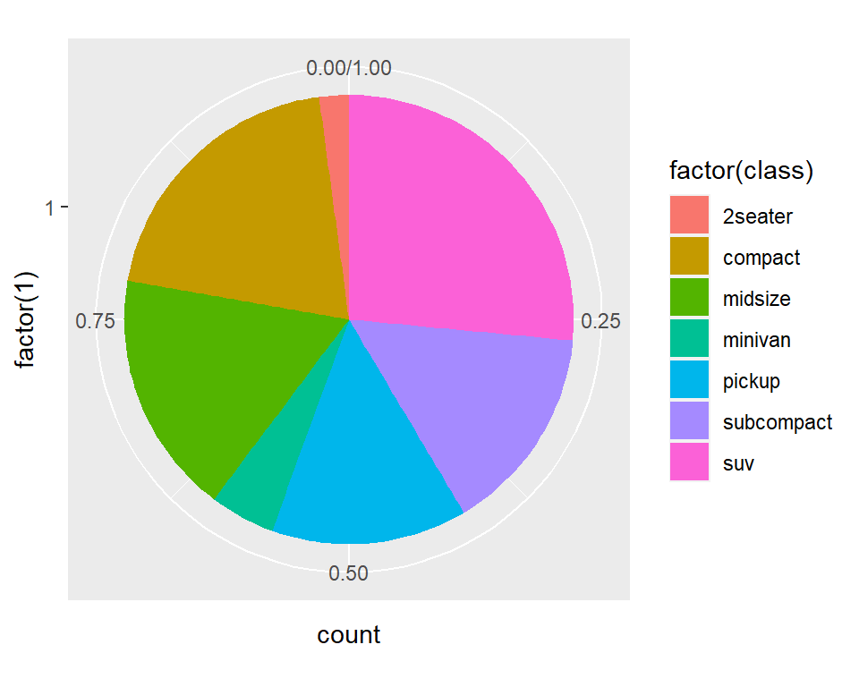

```r
ggplot(mpg, aes(x = factor(1), fill = factor(class))) +
  geom_bar(position = "fill") +
  coord_polar(theta = "y")
```

# 8 ドーナツチャート

- ggpubr::ggdonutchart

## 8.1 基本

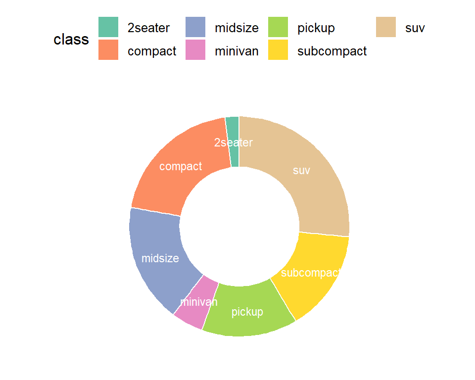

```r
library(ggpubr)

# パーセント(%の前の部分の数字)のデータを別途作成
percent <-
  mpg %>%
  count(class) %>%
  mutate(pct = n/sum(n)*100,
         pctp = scales::percent_format(accuracy = 0.1)(n/sum(n))) # %付きの値も作成


ggdonutchart(percent, "pct", label = "class",
      fill = "class",
      color = "white", # 区分線の色
      lab.pos = "in",
      lab.font = c(3, "white")) + # ラベルの文字サイズ、色
    scale_fill_brewer(palette = "Set2")
```

# 9 ビースウォーム（蜂峰図、蜂群図）

- `ggbeeswarm`パッケージを使う（ここだけで使うので`ggbeeswarm::`をつける）

## 9.1 デフォルトの図

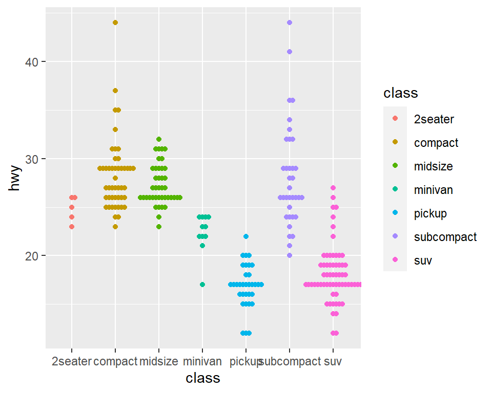

```r
pch <-
ggplot(mpg, aes(class, hwy))


pch +
  ggbeeswarm::geom_beeswarm(aes(color = class)) # 色分けに指定する変数
```

# 10 バイオリンプロット

## 10.1 デフォルトの図

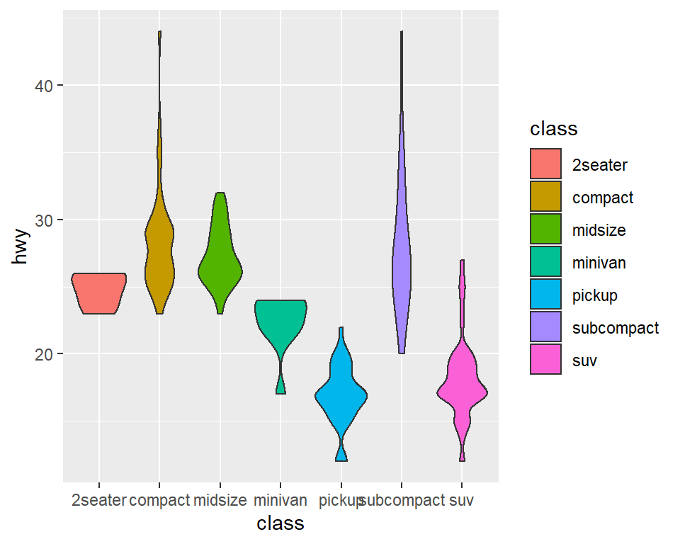

```r
pch +
  geom_violin(aes(fill = class))  # 色分けに指定する変数
```

### 10.1.1 濃さ（透明度）

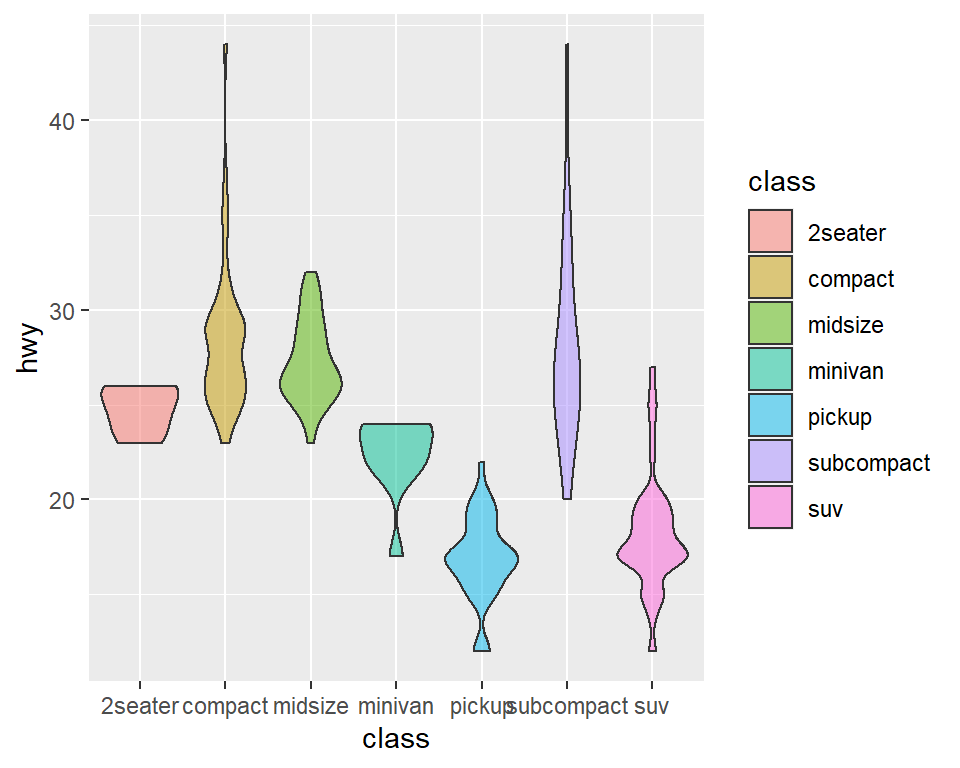

```r
pch + geom_violin(aes(fill = class),
                  alpha = 0.5)
```

# 11 ハーフバイオリン・ハーフドットプロット

## 11.1 デフォルトの図

- `see`パッケージの`geom_violindot()`を使う
- ドットサイズのデフォルトが0.7なのでここだけ大きくした

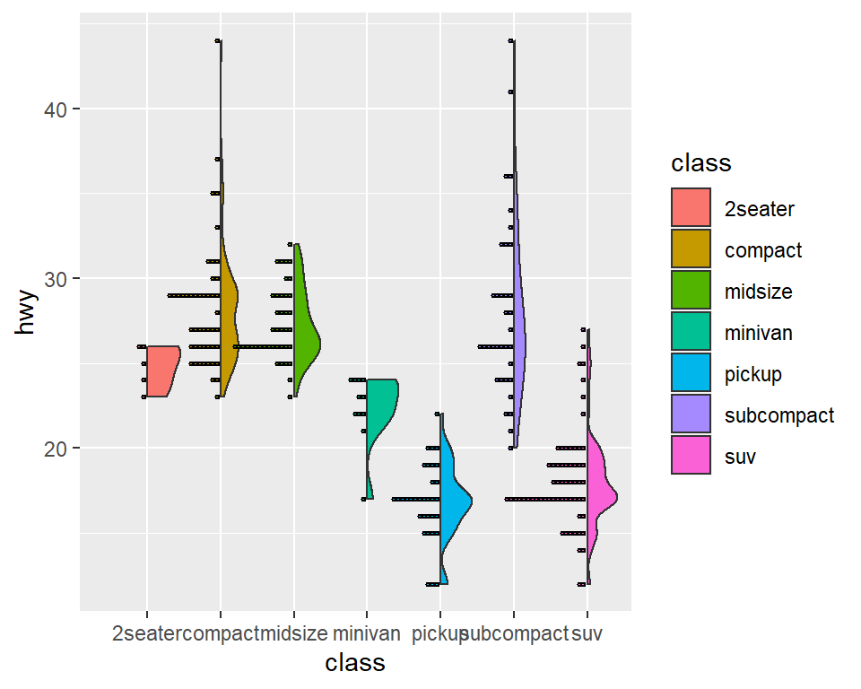

```r
pch +
  geom_violindot(aes(fill = class),
                     size_dots = 5) # ドットサイズ変更
```

# 12 複数のグラフを1枚にまとめる

- 色々なやり方があるけどまずは基本的な所から（徐々に拡充予定）
- 参考：https://cran.r-project.org/web/packages/egg/vignettes/Ecosystem.html

## 12.1 一行または一列

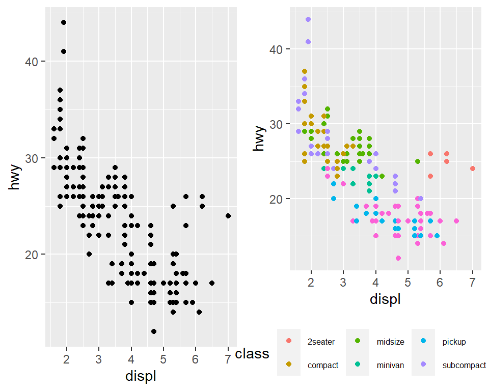

```r
library(gridExtra)

p1 <- p + geom_point()
p2 <-
  pc +
  geom_point() +
   theme(legend.text = element_text(size = 6),# 凡例のテキストを小さく
         legend.position = "bottom",          # 凡例を下に
         legend.background = element_blank()) # 凡例のボックス背景を透明に


grid.arrange(p1, p2, nrow = 1) # 1行に
```

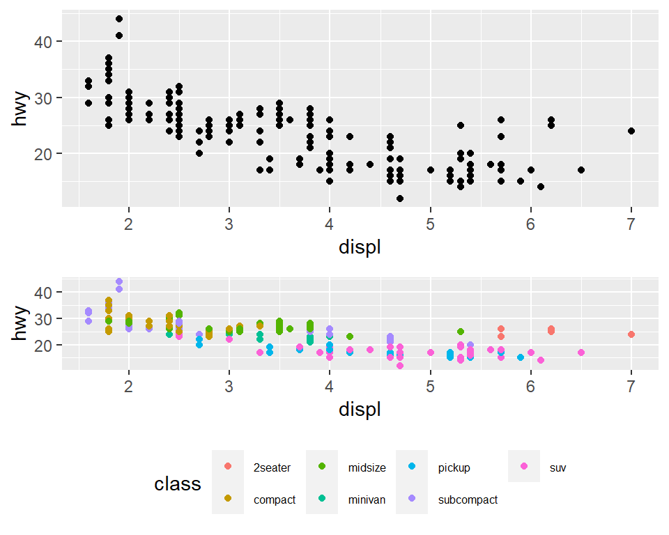

```r
grid.arrange(p1, p2, ncol = 1) # 1列に
```

## 12.2 四等分（2x2）

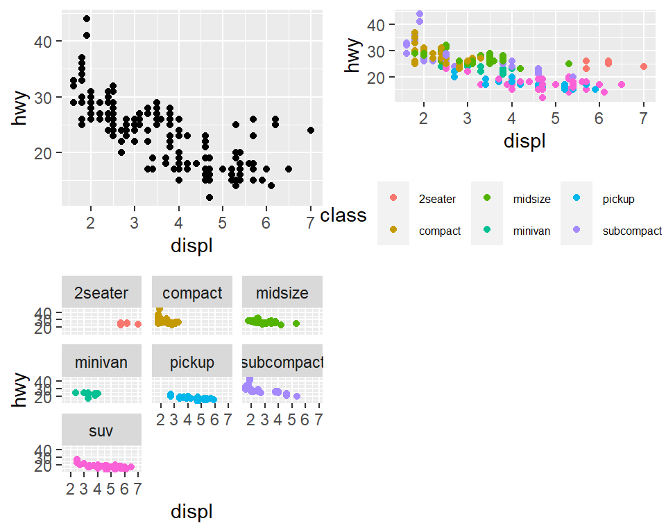

```r
p3 <-
pc +
   geom_point() +
   facet_wrap(vars(class)) +
 theme(legend.position = "none") # 凡例を消す

grid.arrange(p1, p2, p3, ncol = 2) # 2列に
```